# South Sudan resilience

Trauma review

Dan Killian

1/7/2022

# 1 Introduction

The South Sudan Monitoring and Evaluation Support Project (MESP) is conducting a household resilience survey in 13 counties. The purpose of this household survey is to obtain baseline data in the target areas for the indicators included in the Mission’s Performance Management Plan (PMP) and the Community Roadmap, in support of USAID/South Sudan’s Strategic Framework (2020-2024).

# 2 Experience of trauma

The survey asks six questions pertaining to the incidence of trauma. The preparatory text explains that trauma occurs when distressing events cause stress that changes a person’s thinking, feelings, behavior, interpersonal relationships, physical well-being, or functioning for daily activities. The following table shows these item frequencies.

```r
trauma <- dat %>%
  select(q_711,
         q_715,
         q_719,
         q_723,
         q_727,
         q_731)

dat <- dat %>%
  mutate(trauma_thoughts = case_when(q_711 == 1 ~ 1,
                                     TRUE ~ 0),
         trauma_feelings = case_when(q_715 == 1 ~ 1,
                                     TRUE ~ 0),
         trauma_behavior = case_when(q_719 == 1 ~ 1,
                                     TRUE ~ 0),
         trauma_relations = case_when(q_723 == 1 ~ 1,
                                     TRUE ~ 0),
         trauma_physical = case_when(q_727 == 1 ~ 1,
                                     TRUE ~ 0),
         trauma_function = case_when(q_731 == 1 ~ 1,
                                     TRUE ~ 0))

trauma <- dat %>%
  select(trauma_thoughts:trauma_function)

#trauma_out <- trauma %>%
#  summarize(trauma_thoughts=mean(trauma_thoughts))

trauma_out <- svyrdat %>%
  group_by() %>%
  summarize(trauma_thoughts=survey_mean(trauma_thoughts),
            trauma_feelings=survey_mean(trauma_feelings),
            trauma_behavior=survey_mean(trauma_behavior),
            trauma_relations=survey_mean(trauma_relations),
            trauma_physical=survey_mean(trauma_physical),
            trauma_function=survey_mean(trauma_function)) %>%
  select(1,3,5,7,9,11) %>%
  t() %>%
  as.data.frame() %>%
  rownames_to_column("var_name") %>%
  mutate(item_num=c("q_711","q_715","q_719","q_723", "q_727","q_731"),
         Description=c("Problems with thinking",
                       "Problems with emotions",
                       "Problems with behavior",
                       "Problems with relationships",
                       "Problems with physical symptoms",
                       "Problems with physical functioning")) %>%
  select(var_name, item_num, Description, Percent=V1) %>%
  arrange(desc(Percent))

trauma_out
```

| var_name | item_num | Description | Percent |
| --- | --- | --- | --- |
| trauma_thoughts | q_711 | Problems with thinking | 0.599 |
| trauma_physical | q_727 | Problems with physical symptoms | 0.582 |
| trauma_feelings | q_715 | Problems with emotions | 0.544 |
| trauma_relations | q_723 | Problems with relationships | 0.492 |
| trauma_behavior | q_719 | Problems with behavior | 0.485 |
| trauma_function | q_731 | Problems with physical functioning | 0.419 |

```r
trauma_out_gt <- trauma_out %>%
  gt() %>%
  fmt_percent(4,
             decimals=1)

trauma_out_gt
```

| var_name | item_num | Description | Percent |
| --- | --- | --- | --- |
| trauma_thoughts | q_711 | Problems with thinking | 59.9% |
| trauma_physical | q_727 | Problems with physical symptoms | 58.2% |
| trauma_feelings | q_715 | Problems with emotions | 54.4% |
| trauma_relations | q_723 | Problems with relationships | 49.2% |
| trauma_behavior | q_719 | Problems with behavior | 48.5% |
| trauma_function | q_731 | Problems with physical functioning | 41.9% |

```r
trauma_temp <- svyrdat %>%
  group_by() %>%
  summarize(trauma_thoughts=survey_mean(trauma_thoughts),
            trauma_feelings=survey_mean(trauma_feelings),
            trauma_behavior=survey_mean(trauma_behavior),
            trauma_relations=survey_mean(trauma_relations),
            trauma_physical=survey_mean(trauma_physical),
            trauma_function=survey_mean(trauma_function))


trauma_mn <- trauma_temp %>%
  select(!contains("se")) %>%
  t() %>%
  as.data.frame() %>%
  rownames_to_column("item") %>%
  rename(percent=V1)

trauma_mn
```

| item | percent |
| --- | --- |
| trauma_thoughts | 0.599 |
| trauma_feelings | 0.544 |
| trauma_behavior | 0.485 |
| trauma_relations | 0.492 |
| trauma_physical | 0.582 |
| trauma_function | 0.419 |

```r
trauma_se <- trauma_temp %>%
  select(contains("se")) %>%
  t() %>%
  as.data.frame() %>%
#  rownames_to_column("conflict") %>%
  rename(se=V1)

trauma_se
```

| se |
| --- |
| 0.0193 |
| 0.0194 |
| 0.0188 |
| 0.0176 |
| 0.0194 |
| 0.0186 |

```r
trauma_sum <- trauma_mn %>%
  cbind(trauma_temp[,2]) %>%
  rename(se=3) %>%
  mutate(lower=percent-1.96*se,
         upper=percent+1.96*se,
         item_num=c("q_711","q_715","q_719","q_723", "q_727","q_731"),
         Description=c("Problems with thinking",
                       "Problems with emotions",
                       "Problems with behavior",
                       "Problems with relationships",
                       "Problems with physical symptoms",
                       "Problems with physical functioning")) %>%
   select(1, 6:7, everything())

trauma_sum
```

| item | item_num | Description | percent | se | lower | upper |
| --- | --- | --- | --- | --- | --- | --- |
| trauma_thoughts | q_711 | Problems with thinking | 0.599 | 0.0193 | 0.561 | 0.637 |
| trauma_feelings | q_715 | Problems with emotions | 0.544 | 0.0193 | 0.506 | 0.582 |
| trauma_behavior | q_719 | Problems with behavior | 0.485 | 0.0193 | 0.447 | 0.523 |
| trauma_relations | q_723 | Problems with relationships | 0.492 | 0.0193 | 0.454 | 0.53 |
| trauma_physical | q_727 | Problems with physical symptoms | 0.582 | 0.0193 | 0.544 | 0.62 |
| trauma_function | q_731 | Problems with physical functioning | 0.419 | 0.0193 | 0.381 | 0.457 |

```r
write_csv(trauma_sum, here("output/tables/trauma items.csv"))

trauma_gt <- trauma_sum %>%
  select(-5) %>%
  gt() %>%
  fmt_percent(4:6,
              decimals=1)

trauma_gt
```

| item | item_num | Description | percent | lower | upper |
| --- | --- | --- | --- | --- | --- |
| trauma_thoughts | q_711 | Problems with thinking | 59.9% | 56.1% | 63.7% |
| trauma_feelings | q_715 | Problems with emotions | 54.4% | 50.6% | 58.2% |
| trauma_behavior | q_719 | Problems with behavior | 48.5% | 44.7% | 52.3% |
| trauma_relations | q_723 | Problems with relationships | 49.2% | 45.4% | 53.0% |
| trauma_physical | q_727 | Problems with physical symptoms | 58.2% | 54.4% | 62.0% |
| trauma_function | q_731 | Problems with physical functioning | 41.9% | 38.1% | 45.7% |

```r
gtsave(trauma_gt, here("output/tables/trauma items.rtf"))
```

```r
trauma_mn <- svyrdat %>%
  group_by() %>%
  summarize(trauma=survey_mean(trauma, na.rm=T))

trauma_mn
```

| trauma | trauma_se |
| --- | --- |
| 0.772 | 0.0148 |

```r
trauma_cnty <- svyrdat %>%
  group_by(county) %>%
  summarize(se = std.error(trauma),
            trauma=mean(trauma, na.rm=T)) %>%
  mutate(lower=trauma-1.96*se,
         upper=trauma+1.96*se) %>%
  select(1,3:5) %>%
  arrange(desc(trauma))

trauma_cnty
```

| county | trauma | lower | upper |
| --- | --- | --- | --- |
| Pibor | 0.968 | 0.953 | 0.982 |
| Uror | 0.827 | 0.796 | 0.857 |
| Duk | 0.814 | 0.781 | 0.848 |
| Kapoeta North | 0.774 | 0.741 | 0.808 |
| Paynijar | 0.76 | 0.726 | 0.794 |
| Ulang | 0.746 | 0.712 | 0.78 |
| Akobo | 0.727 | 0.692 | 0.762 |
| Mayendit | 0.678 | 0.641 | 0.715 |
| Budi | 0.63 | 0.592 | 0.668 |
| Leer | 0.61 | 0.572 | 0.649 |
| Baliet | 0.584 | 0.545 | 0.623 |
| Wau | 0.563 | 0.524 | 0.603 |
| Jur River | 0.455 | 0.415 | 0.495 |

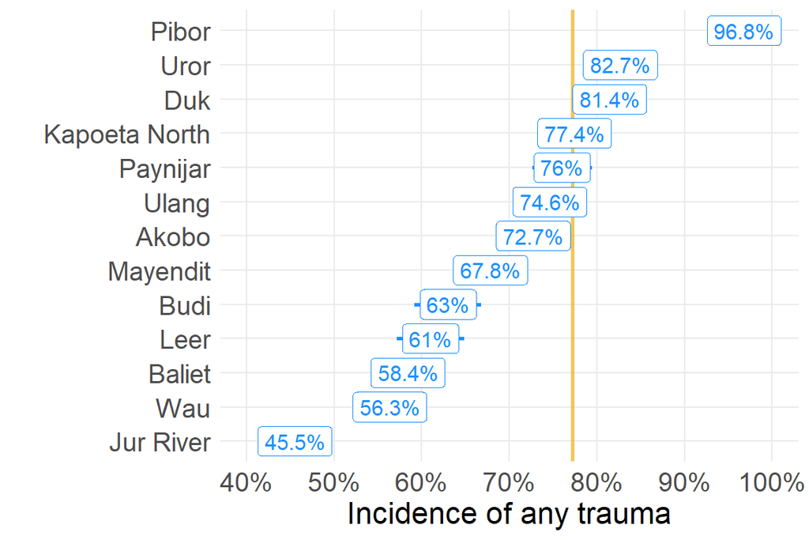

```r
ggplot(trauma_cnty, aes(trauma, fct_reorder(county, trauma))) +
  geom_vline(xintercept=trauma_mn[,1], size=1, alpha=.7, color="darkgoldenrod2") +
  #geom_vline(xintercept=4, size=1, alpha=.7, color="aquamarine3") +
  geom_point(color="dodgerblue", size=3) +
  geom_errorbar(aes(xmin=lower, xmax=upper),
                color="dodgerblue",
                width=0,
                size=1) +
  geom_label(aes(label=paste(round(trauma,3)*100, "%", sep="")), size=4, color="dodgerblue") +
  scale_x_continuous(limits=c(.4,1),
                     breaks=seq(.4,1, .1),
                     labels=percent_format(accuracy=1)) +
  labs(x="Incidence of any trauma",
       y="")
```

```r
ggsave(here("output/viz/any trauma, by county label.png"),
       type="cairo",
       device="png",
       height=4,
       width=7)
```

# 3 Factor analysis

Using a composite variable for any sort of trauma is of uncertain utility. It may be more of interest to think of trauma as a psychosocial condition resulting from the stress of a household dealing with its schedule of shocks and stresses. We can conduct additional analysis to investigate whether the trauma variables cluster around specific types of trauma.

### 3.0.1 Three factor model

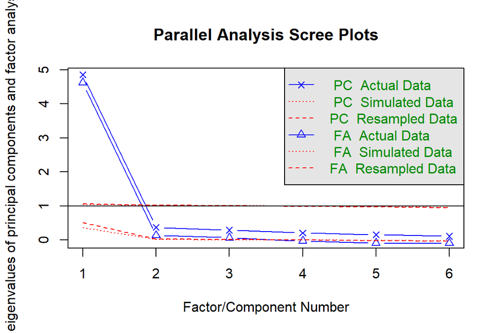

```
## Parallel analysis suggests that the number of factors =  3  and the number of components =  1
```

```r
fa.parallel(trauma,
            cor="tet")
```

```r
trauma_fa_3 <- fa(trauma,
                  nfactors=3,
                  cor="tet",
                  fm="ml",
                  scores="tenBerge")
```

```r
trauma_fa_3
```

```
## Factor Analysis using method =  ml
## Call: fa(r = trauma, nfactors = 3, scores = "tenBerge", fm = "ml",
##     cor = "tet")
## Standardized loadings (pattern matrix) based upon correlation matrix
##                   ML1   ML3   ML2   h2    u2 com
## trauma_thoughts  0.24  0.50  0.20 0.76 0.236 1.8
## trauma_feelings  0.00  0.98  0.02 1.00 0.005 1.0
## trauma_behavior  0.90  0.15 -0.12 0.88 0.125 1.1
## trauma_relations 0.91 -0.08  0.10 0.86 0.138 1.0
## trauma_physical  0.03  0.07  0.92 1.00 0.005 1.0
## trauma_function  0.62  0.02  0.26 0.74 0.259 1.3
##
##                        ML1  ML3  ML2
## SS loadings           2.43 1.52 1.28
## Proportion Var        0.41 0.25 0.21
## Cumulative Var        0.41 0.66 0.87
## Proportion Explained  0.46 0.29 0.24
## Cumulative Proportion 0.46 0.76 1.00
##
##  With factor correlations of
##      ML1  ML3  ML2
## ML1 1.00 0.82 0.79
## ML3 0.82 1.00 0.69
## ML2 0.79 0.69 1.00
##
## Mean item complexity =  1.2
## Test of the hypothesis that 3 factors are sufficient.
##
## The degrees of freedom for the null model are  15  and the objective function was  6.21 with Chi Square of  48853
## The degrees of freedom for the model are 0  and the objective function was  0
##
## The root mean square of the residuals (RMSR) is  0
## The df corrected root mean square of the residuals is  NA
##
## The harmonic number of observations is  7872 with the empirical chi square  3.57  with prob <  NA
## The total number of observations was  7872  with Likelihood Chi Square =  35.1  with prob <  NA
##
## Tucker Lewis Index of factoring reliability =  -Inf
## Fit based upon off diagonal values = 1
## Measures of factor score adequacy
##                                                    ML1  ML3  ML2
## Correlation of (regression) scores with factors   0.97 1.00 1.00
## Multiple R square of scores with factors          0.95 0.99 0.99
## Minimum correlation of possible factor scores     0.89 0.99 0.99
```

The second factor (ML3) is built on problems with feelings and thoughts.

The third factor (ML2) is built on problems with physical symptoms.

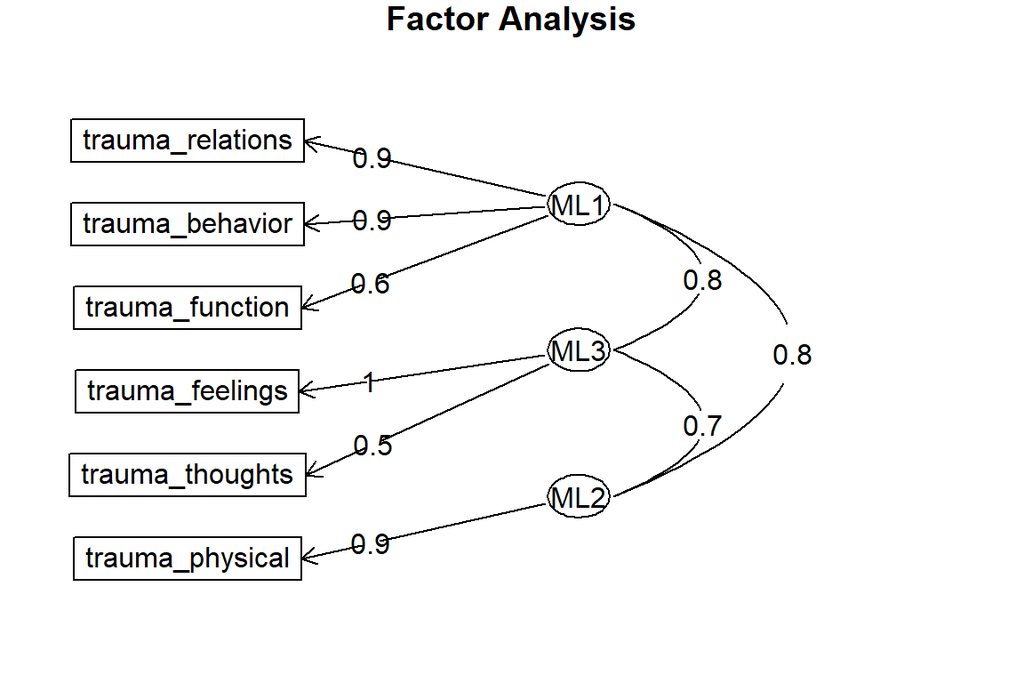

```r
fa.diagram(trauma_fa_3)
```

For purposes of using a measure of psychosocial stress to help model household resilience, we might consider ML3 (problems with thoughts and feelings) to be the factor that best captures a generalized measure of mental or emotional stress. Problems with personal relationships and behavior (ML1) may capture behavioral issues unrelated to stress from the environment, while problems with physical symptoms (ML2) may capture sickness or injury that is unrelated to stress from the environment. In the three-factor model, the ‘stress’ factor accounts for 25 percent of the variance across the six trauma items.

# 4 Psychosocial stress

Alternatively, and for purposes of simplicity, we may also use the survey item for problems with feelings/emotions.

```r
feelings_mn <- svyrdat %>%
  group_by() %>%
  summarize(trauma_feelings=survey_mean(trauma_feelings, na.rm=T))

feelings_mn
```

| trauma_feelings | trauma_feelings_se |
| --- | --- |
| 0.544 | 0.0194 |

```r
feelings_cnty <- svyrdat %>%
  group_by(county) %>%
  summarize(se = std.error(trauma),
            trauma_feelings=mean(trauma_feelings, na.rm=T)) %>%
  mutate(lower=trauma_feelings-1.96*se,
         upper=trauma_feelings+1.96*se) %>%
  select(1,3:5) %>%
  arrange(desc(trauma_feelings))

feelings_cnty
```

| county | trauma_feelings | lower | upper |
| --- | --- | --- | --- |
| Pibor | 0.913 | 0.898 | 0.928 |
| Ulang | 0.637 | 0.603 | 0.672 |
| Duk | 0.633 | 0.6 | 0.667 |
| Paynijar | 0.568 | 0.534 | 0.602 |
| Kapoeta North | 0.506 | 0.472 | 0.539 |
| Mayendit | 0.47 | 0.433 | 0.508 |
| Akobo | 0.461 | 0.426 | 0.496 |
| Budi | 0.445 | 0.407 | 0.483 |
| Uror | 0.409 | 0.379 | 0.439 |
| Leer | 0.403 | 0.365 | 0.442 |
| Baliet | 0.294 | 0.255 | 0.333 |
| Jur River | 0.278 | 0.239 | 0.318 |
| Wau | 0.26 | 0.221 | 0.299 |

```r
write_csv(feelings_cnty, here("output/tables/trauma feelings by county.csv"))

feelings_cnty_gt <- feelings_cnty %>%
  gt() %>%
  fmt_percent(2:4, decimals=1)

feelings_cnty_gt
```

| county | trauma_feelings | lower | upper |
| --- | --- | --- | --- |
| Pibor | 91.3% | 89.8% | 92.8% |
| Ulang | 63.7% | 60.3% | 67.2% |
| Duk | 63.3% | 60.0% | 66.7% |
| Paynijar | 56.8% | 53.4% | 60.2% |
| Kapoeta North | 50.6% | 47.2% | 53.9% |
| Mayendit | 47.0% | 43.3% | 50.8% |
| Akobo | 46.1% | 42.6% | 49.6% |
| Budi | 44.5% | 40.7% | 48.3% |
| Uror | 40.9% | 37.9% | 43.9% |
| Leer | 40.3% | 36.5% | 44.2% |
| Baliet | 29.4% | 25.5% | 33.3% |
| Jur River | 27.8% | 23.9% | 31.8% |
| Wau | 26.0% | 22.1% | 29.9% |

```r
gtsave(feelings_cnty_gt, here("output/tables/trauma feelings by county.rtf"))
```

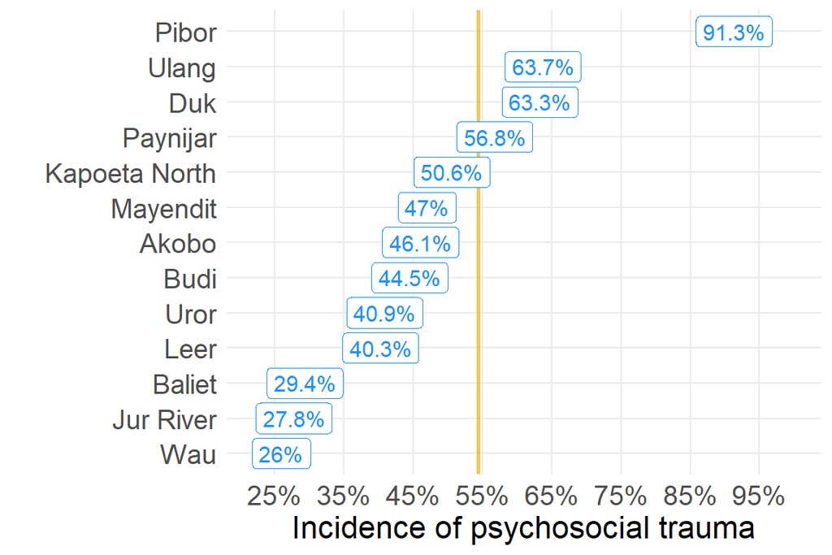

```r
ggplot(feelings_cnty, aes(trauma_feelings, fct_reorder(county, trauma_feelings))) +
  geom_vline(xintercept=feelings_mn[,1], size=1, alpha=.7, color="darkgoldenrod2") +
  #geom_vline(xintercept=4, size=1, alpha=.7, color="aquamarine3") +
  geom_point(color="dodgerblue", size=3) +
  geom_errorbar(aes(xmin=lower, xmax=upper),
                color="dodgerblue",
                width=0,
                size=1) +
  geom_label(aes(label=paste(round(trauma_feelings,3)*100, "%", sep="")), size=4, color="dodgerblue") +
  scale_x_continuous(limits=c(.22,1),
                     breaks=seq(.25,1, .1),
                     labels=percent_format(accuracy=1)) +
  labs(x="Incidence of psychosocial trauma",
       y="")
```

```r
ggsave(here("output/viz/psychosocial trauma, by county label.png"),
       type="cairo",
       device="png",
       height=4,
       width=7)
```